# ctmcd: An R Package for Estimating the Parameters of a Continuous-Time Markov Chain from Discrete-Time Data

This article introduces the R package *ctmcd*, which provides an implementation of methods for the estimation of the parameters of a continuous-time Markov chain given that data are only available on a discrete-time basis. This data consists of partial observations of the state of the chain, which are made without error at discrete times, an issue also known as the embedding problem for Markov chains. The functions provided comprise matrix logarithm based approximations as described in Israel et al. (2001), as well as Kreinin and Sidelnikova (2001), an expectation-maximization algorithm and a Gibbs sampling approach, both introduced by Bladt and Sørensen (2005). For the expectation-maximization algorithm Wald confidence intervals based on the Fisher information estimation method of Oakes (1999) are provided. For the Gibbs sampling approach, equal-tailed credibility intervals can be obtained. In order to visualize the parameter estimates, a matrix plot function is provided. The methods described are illustrated by Standard and Poor’s discrete-time corporate credit rating transition data.

Marius Pfeuffer (Department of Statistics and Econometrics, University of Erlangen-Nuremberg)  
2017-07-28

## 1 Introduction

The estimation of the parameters of a continuous-time Markov chain (see, e.g., Norris (1998) or Ethier and Kurtz (2005); also referred to as Markov process) when only discrete time observations are available is a widespread problem in the statistical literature. Dating back to Elfving (1937), this issue is also known as the embedding problem for discrete-time Markov chains. The problem occurs in the modeling of dynamical systems when due to various reasons such as a difficult measurement procedure only discrete-time observations are available. This is the case in a wide range of applications, e.g., in the analysis of gene sequence data (see, e.g., Hobolth and Stone (2009), Verbyla et al. (2013) or Chen et al. (2014)), for causal inference in epidemiology (see, e.g., Zhang and Small (2012)), for describing the dynamics of open quantum systems (see, e.g., Cubitt et al. (2012)), or in rating based credit risk modeling (see, e.g., Dorfleitner and Priberny (2013), Yavin et al. (2014) or Hughes and Werner (2016)) to name only a few.

In the following, an explicit statement of the missing data setting shall be given and the notation used in this manuscript shall be introduced: Consider that realizations of a continuous-time Markov chain, i.e., paths of states $s\in\left\{ 1,\ldots, S\right\}$, which change at times $\tau_1,\ldots,\tau_K$ are given. For a single path, this is exemplarily illustrated in figure 1.

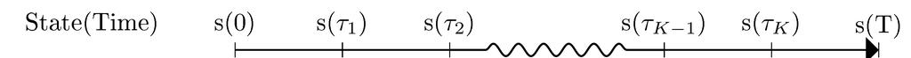

Figure 1: Discrete-Time / Continuous-Time Setting

In the missing data situation described in this paper, these paths are however not completely observed, but only at points in time $0$ and $T$. The available observations are thus the states $s(0)$ and $s(T)$ and these states are assumed to be observed without error. The cumulative discrete-time data over all paths can be summarized into conditional transition matrices with absolute transition frequencies $\mathbf{N}_{T|0}$ or relative transition frequencies $\mathbf{P}_{T|0}$ (in the following, the abbreviate notations $\mathbf{N}_{T}$ and $\mathbf{P}_{T}$ will be used). The continuous-time state changes $s(\tau_k), k\in \left\{1,\ldots,K\right\}$ are latent variables.

A continuous-time Markov chain has the parameter set
$$\mathbf{Q}=\{q_{ij}\}_{1\leq i\leq I,1\leq j\leq J, I=J=S}: q_{ii}\leq 0, q_{ij, i \neq j} \geq 0, \sum_{j=1}^J q_{ij}=0,$$
which is called generator matrix, transition rate matrix or intensity matrix. The problem is now to estimate the parameters $\mathbf{Q}$ from the partial observations at times $0$ and $T$. This allows to derive a matrix of conditional discrete-time state change predictions $\mathbf{P}_{T_a}$ for arbitrary time intervals $[0,T_a]$ of length $T_a$ by employing the matrix exponential function
$$\mathbf{P}_{T_a}=\exp(\mathbf{Q}T_a).$$

Besides the R package [*msm*](https://CRAN.R-project.org/package=msm), see Jackson et al. (2011), which only provides functions for direct likelihood optimization, there is no other publicly accessible implementation available which allows for estimating the parameters of a continuous-time Markov chain given that data have been only observed on a discrete-time basis. Against this background, this paper introduces the R package [*ctmcd*](https://CRAN.R-project.org/package=ctmcd), a continuously extended, improved and documented implementation based of what started as supplementary R code to Pfeuffer (2016). The functions of the package are explained and illustrated by Standard and Poor’s corporate rating transition data. The outline of the paper is as follows: first, three matrix logarithm adjustment approaches are explained. Second, likelihood inference is illustrated for an instance of the expectation-maximization algorithm. Third, the implementation of a Gibbs sampler is presented to facilitate Bayesian inference. Numerical properties of the different approaches are evaluated and examples for more complex applications of the methods are shown. Finally, the results of the paper are summarized.

## 2 Matrix logarithm adjustment approaches

A basic approach to estimate generator matrices from discrete-time observations is to inversely use the matrix exponential relationship between conditional discrete time transition matrices $\mathbf{P}_{T}$ (the cumulative discrete-time state change data) and the parameters $\mathbf{Q}$, i.e., to employ a matrix logarithm function, which leads to the estimate
$$\mathbf{Q}_{c}=\log(\mathbf{P}_{T})=\sum_{k=1}^\infty \frac{(-1)^{k+1}}{k}(\mathbf{P}_{T}-\mathbf{I})^k.$$
Besides finite truncation of this Taylor series, the matrix logarithm can, e.g., also be calculated by an eigendecomposition, which is the default setting in *ctmcd*.

However, the matrix logarithm approach has two shortcomings. First, the matrix logarithm is not a bijective function. As, e.g., shown by Speakman (1967), a transition matrix can have more than one valid generator. However, for a certain subset of discrete-time transition matrices, it can be shown that there exists only a single unique generator, for details on criteria (for discrete-time transition matrices) under which this is the case, see, e.g., Cuthbert (1972), Cuthbert (1973), Singer and Spilerman (1976) or Israel et al. (2001). Second, the method requires that the derived matrix $\mathbf{Q}_c$ actually meets the above outlined parameter constraints for Markov generator matrices, concretely that off diagonal elements are non-negative, which is not necessarily the case. Therefore, in the following we shall discuss techniques for adjusting logarithms of the discrete time data matrices $\mathbf{P}_{T}$, so that proper generator matrices can be derived.

### 2.1 Diagonal and weighted adjustment

In this context, Israel et al. (2001) introduce two approaches. On the one hand, **diagonal adjustment (DA)** works by forcing negative off-diagonal elements of $\mathbf{Q}_c$ to zero
$$q_{ij,i\neq j}=0|q_{ij,c}<0$$
and adjusting the diagonal elements
$$q_{ii}=-\sum_{j=1}^J q_{ij}$$
to ensure that $\sum_{j=1}^J q_{ij}=0$. In *ctmcd* such an estimate can be performed by passing `method="DA"` to `gm()`, the generic generator matrix estimation function of the package. The method requires the specification of a discrete time transition matrix `tm`, which in the case of matrix logarithm adjustment approaches is a matrix of **relative** transition frequencies, which refers to the matrix $\mathbf{P}_{T}$ introduced above, as input data.

In order to illustrate the methods, we employ Standard and Poor’s (2000) global corporate credit ratings data. The rating categories in this data set have the commonly known symbols $AAA$, $AA$, $A$, $BBB$, $BB$, $B$, $C$ and $D$. These abbreviations represent states of decreasing credit quality whereas category $D$ stands for the event of credit default, which means that if rated $D$ the obligor cannot or does not have the willingness to meet its financial obligations any more. The data is provided as `tm_abs` a matrix of discrete-time absolute transition frequencies from the first to the last day of the fiscal year 2000. We have to take into account that the default category $D$ has to be considered as an absorbing state, because once an obligor has defaulted it can not escape this state any more. Following the intuitive ordering of decreasing credit quality described above, in this example the default state will refer to row $8$. Thus, in order to convert the data into the required format, we have to create a matrix of relative transition frequencies `tm_rel` by standardizing the row entries to sum to $1$ and adding a unit row vector as row $8$ with the last entry of this row being $1$. Subsequently, we can apply the diagonal adjustment approach by specifying `tm=tm_rel` and the time horizon of this discrete-time matrix as `te=1`, because `tm_abs` and `tm_rel` refer to credit rating changes for a single year time interval (fiscal year 2000).

```r
  data(tm_abs)
  tm_rel <- rbind((tm_abs / rowSums(tm_abs))[1:7,], c(rep(0, 7), 1))
  gmda <- gm(tm=tm_rel, te=1, method="DA")
```

On the other hand, Israel et al. (2001) also describe the **weighted adjustment (WA)** of the non-negative off-diagonal entries as an alternative, i.e., off diagonal elements are adjusted by
$$q_{ij, i\neq j}=q_{ij,c}+\frac{|q_{ij,c}|}{\sum_{j\neq i}|q_{ij,c}|}\sum_{j\neq i} q_{ij,c}1(q_{ij,c}<0)|q_{ij,c} \geq 0,$$

where the cut off jump probability mass is redistributed among the remaining positive off diagonal elements according to their absolute values. In analogy to diagonal adjustment, a weighted adjustment estimate can be derived by using `method="WA"` as follows:

```r
  gmwa <- gm(tm=tm_rel, te=1, method="WA")
```

### 2.2 Quasi-optimization

The third matrix logarithm adjustment approach is the **quasi-optimization (QO)** procedure of Kreinin and Sidelnikova (2001). This method finds a generator $\mathbf{Q}$ from the set of all possible generator matrices $\mathbf{Q^\prime}$ by solving the minimization problem
$$\mathbf{Q} = \arg \min_{\mathbf{Q}^\prime} \sum_{i=1}^I \sum_{j=1}^J (q^\prime_{ij}-q_{ij,c})^2,$$
which means that the algorithm chooses a generator matrix which is closest to the matrix logarithm in terms of sum of squared deviations.

```r
  gmqo <- gm(tm=tm_rel, te=1, method="QO")
```

By specifying `method="QO"`, we can then get a quasi-optimization approach result for our data. Despite the possibility to just show the parameter estimates for the different methods in the console using, e.g., `print(gmDA)` or simply calling `gmDA()`, *ctmcd* also provides a matrix plot function `plotM()` that especially allows the visualization of generator matrix estimates and can be easily accessed by the generic `plot()` function:

```r
  plot(gmda)
  plot(gmwa)
  plot(gmqo)
```

The results can be seen in figure 2.

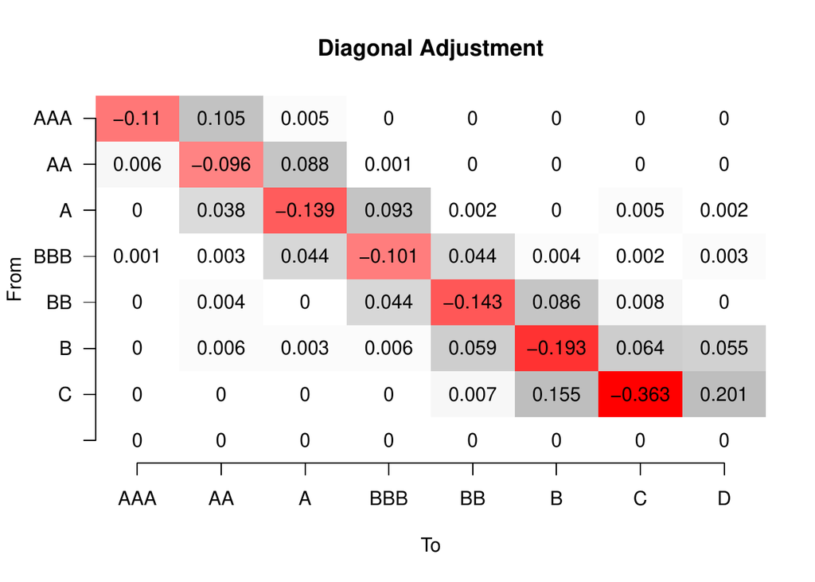

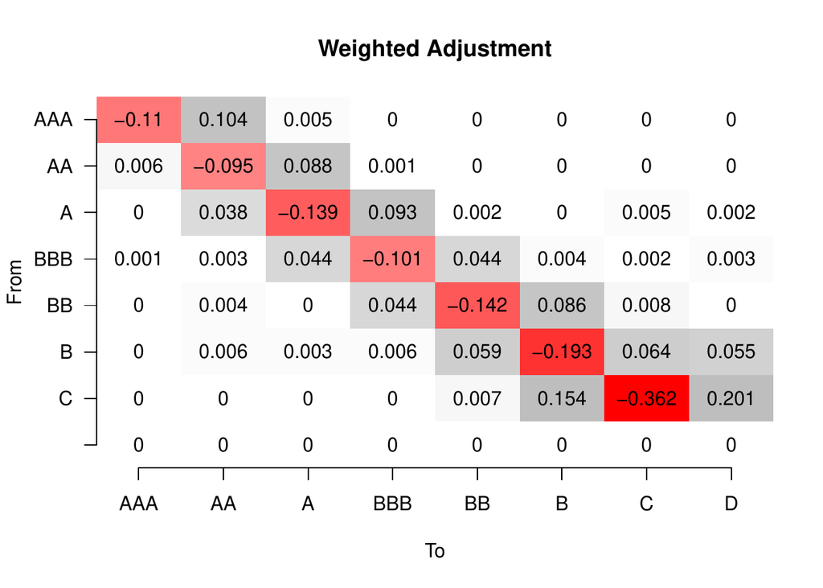

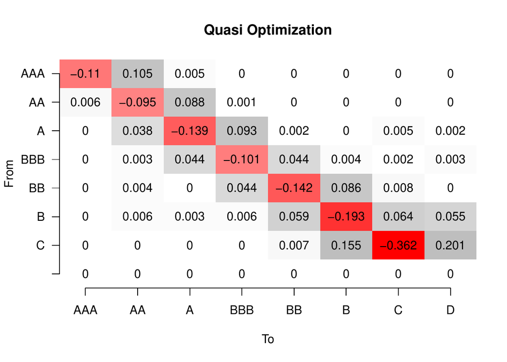

Figure 2: Matrix Logarithm Adjustment Approaches

## 3 Likelihood inference

Given that complete continuous-time data is available, the likelihood function for a generator matrix is given by
$$L(\mathbf{Q})=\prod_{i=1}^I \prod_{j\neq i} q_{ij}^{N_{ij}(T)}\exp(-q_{ij}R_i(T)),$$
where $N_{ij}(T)$ denotes the number of transitions from $i$ to $j$ within time $T$ and $R_i(T)$ for the cumulative sojourn times in state $i$ before a state change occurs. A maximum likelihood estimate for a single off-diagonal element of $\mathbf{Q}$ can then be derived by
$$q_{ij,ML}=\frac{N_{ij}(T)}{R_i(T)},$$
for more information see, e.g., Inamura (2006).

### 3.1 Expectation-maximization algorithm

The difficulty is now that when data is only observed at times $0$ and $T$, the expressions $N_{ij}(T)$ and $R_i(T)$ are not known. In order to derive a maximum likelihood estimate given this partially accessible observations setting, Bladt and Sørensen (2005) derive an instance of the **expectation-maximization** (**EM**) **algorithm**. The missing data is then iteratively imputed by conditional expectations given the current parameter set. This requires a complicated computation of the integrals in
$$\begin{aligned}
E(R_i(T)|\mathbf{Q}_l,s(0),s(T))=&\frac{n_{s(0)s(T)}\mathbf{u}_{s(0)}^T\left(\int_0^T \exp(\mathbf{Q}_lt)\mathbf{u}_i\mathbf{u}_j^T\exp(\mathbf{Q}_l(T-t))dt\right)\mathbf{u}_{s(T)}}{\mathbf{u}_{s(0)}^T\exp(\mathbf{Q}_lT)\mathbf{u}_{s(T)}} \\
\text{and} \quad E(N_{ij}(T)|\mathbf{Q}_l,s(0),s(T))=&\frac{n_{s(0)s(T)}q_{ij,l}\mathbf{u}_{s(0)}^T\left(\int_0^T \exp(\mathbf{Q}_lt)\mathbf{u}_i\mathbf{u}_j^T\exp(\mathbf{Q}_l(T-t))dt\right)\mathbf{u}_{s(T)}}{\mathbf{u}_{s(0)}^T\exp(\mathbf{Q}_lT)\mathbf{u}_{s(T)}},
\end{aligned}$$

where $n$ refers to an element of the discrete-time absolute transition frequency matrix $\mathbf{N}_{T}$, $\mathbf{u}_k$ denotes a unit vector with entry $1$ at position $k$ and $l$ points to the current iteration step of the EM algorithm. The computation of the integrals is carried out following the matrix exponential approach described in van Loan (1978) and Inamura (2006). In order to perform an estimate based on the EM algorithm an initial generator matrix guess has to be chosen, which has to be a proper generator matrix. In the following example, this will be the matrix `gm0`, which is an arbitrarily chosen generator matrix where all off diagonal entries are $1$ and state $8$ is determined as an absorbing state.

```r
gm0 <- matrix(1, 8, 8)
diag(gm0) <- 0
diag(gm0) <- -rowSums(gm0)
gm0[8,] <- 0
```

The maximum likelihood estimate can then be obtained by using the `gm()` function, providing a matrix of absolute numbers of state changes (in the credit rating example i.e., `tm=tm_abs`), specifying the method argument by `method="EM"` and setting an initial guess (here: `gmguess=gm0`).

```r
gmem <- gm(tm=tm_abs, te=1, method="EM", gmguess=gm0)
plot(gmem)
plot(gmem$ll, main="Expectation Maximization Algorithm\nLog Likelihood Path",
     xlab="Iteration", ylab="Log-Likelihood")
```

The result of this estimate can be seen in figure 3 together with a plot of the log-likelihood path of the single EM algorithm iteration steps.

### 3.2 Direct likelihood optimization

```r
### Data transformation for msm function
mig <- NULL
id <- 0
for(i in 1:7) {
  for(j in 1:8) {
    if(tm_abs[i,j] > 0) {
      for(n in 1:tm_abs[i,j]) {
        id <- id + 1
        mig <- rbind(mig, c(id, 0, i), c(id, 1, j))
      }
    }
  }
}
mig_df <- data.frame(id=mig[,1], time=mig[,2], state=mig[,3])

### Comparing estimates
gmem <- gm(tm_abs, te=1, method="EM", eps=1e-7, gmguess=gm0)
ctmcdlogLik(gmem$par, tm_abs, 1)

q0 <- rbind(matrix(1, 7, 8), 0)
msm_est1 <- msm(state ~ time, id, data=mig_df, qmat=q0,
                opt.method="optim", gen.inits=TRUE)
ctmcdlogLik(qmatrix.msm(msm_est)[[1]], tm_abs, 1)
msm_est2 <- msm(state ~ time, id, data=mig_df, qmat=q0,
                opt.method="nlm", gen.inits=TRUE)
ctmcdlogLik(qmatrix.msm(msm_est)[[1]], tm_abs, 1)
msm_est3 <- msm(state ~ time, id, data=mig_df, qmat=q0,
                opt.method="nlm", gen.inits=TRUE)
ctmcdlogLik(qmatrix.msm(msm_est)[[1]], tm_abs, 1)

msm_est4 <- msm(state ~ time, id, data=mig_df, qmat=q0,
                opt.method="fisher", gen.inits=TRUE)
```

The marginal likelihood function for a given generator matrix, discrete-time interval $T$ and corresponding discrete-time transition frequencies $\mathbf{N}_{T}$ can be computed by the function `ctmcdlogLik()`. Optimization with the previously employed remote initial value `gm0` fails for all *msm* optimization methods, with the closer built-in parameter initialization `gen.inits=TRUE`, we obtain the results presented in table 1. Optimization also fails for the method of Kalbfleisch and Lawless (1985). However, it is already mentioned in the helpfiles for the `msm()` function, that optimization using this approach lacks stability. Thus, the advantages of the EM algorithm in this specific data setting where no covariates are included in the calculation are its numerical performance and its stability.

Table 1: Likelihood Optimization - Numerical Comparison

[output not shown]

### 3.3 Confidence intervals

The package *ctmcd* also provides a function for deriving a confidence interval based on the asymptotic normality of the maximum likelihood estimate. As however in a partially observed data setting the maximum likelihood estimate is based on the likelihood function of the complete observations $\{ N_{ij}(T),R_i(T) \}_{1 \leq i \leq I,1\leq j \leq J}$ given that only part of them, $\mathbf{N}_{T}$ are actually available, the Fisher information matrix has to be adjusted for the missing information in order to derive proper standard error estimates. Following Oakes (1999), a Fisher information matrix estimate for the observed data $\mathbf{I}_{\mathbf{N}_{T}}$ can be obtained by
$$\mathbf{I}_{\mathbf{N}_{T}}=\mathbf{I}_{\{ N_{ij}(T),R_i(T) \}_{1 \leq i \leq I,1\leq j \leq J}}-\mathbf{I}_{\{ N_{ij}(T),R_i(T) \}_{1 \leq i \leq I,1\leq j \leq J}|\mathbf{N}_{T}}.$$

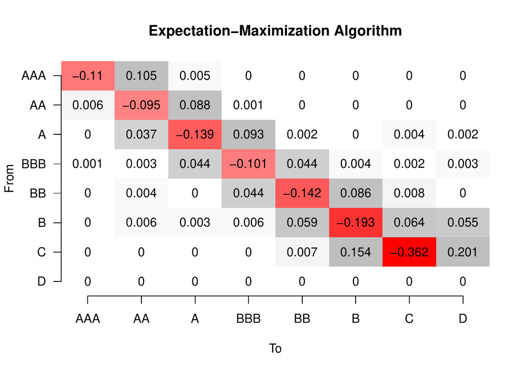

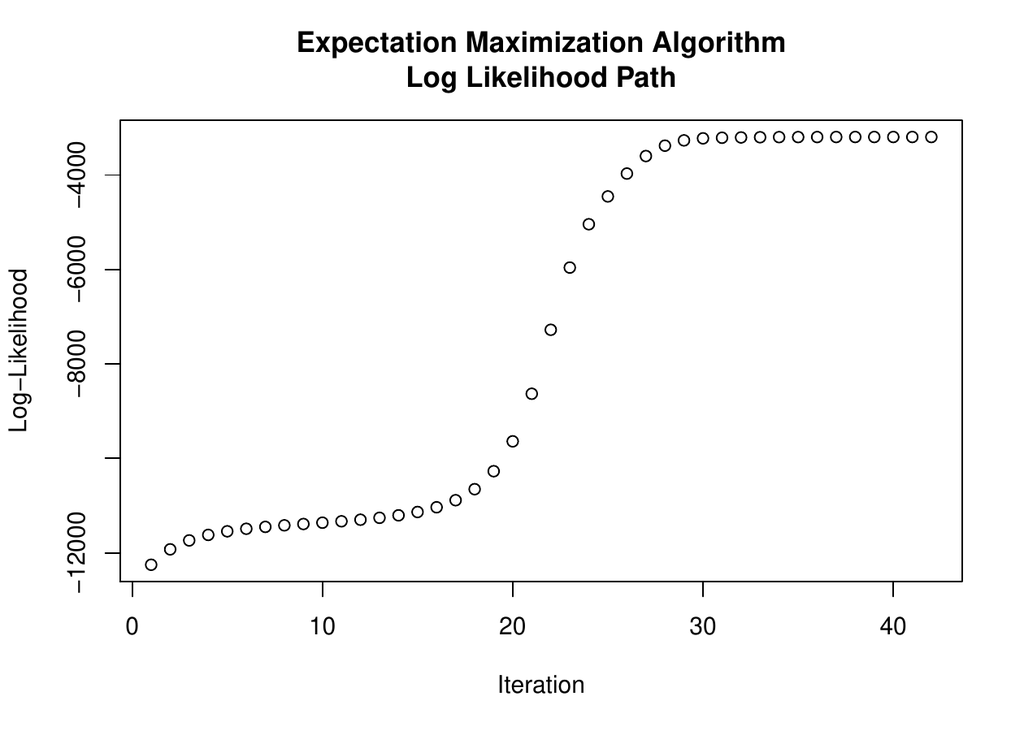

Figure 3: Maximum-Likelihood Estimation.

Bladt and Sørensen (2009) then concretize this expression for a generator matrix estimation framework and derive
$$\begin{aligned}
I_{\mathbf{N}_{T},(i-1)I+j,(i-1)I+j}=&\frac{1}{q_{ij}^2} E(N_{ij}(T)|\mathbf{Q}_l,s(0),s(T))-\frac{1}{q_{ij}^2} \frac{\partial}{\partial q_{ij}} E(N_{ij}(T)|\mathbf{Q}_l,s(0),s(T))\\+&\frac{\partial}{\partial q_{ij}} E(R_{i}(T)|\mathbf{Q}_l,s(0),s(T))\\
\text{and} \quad I_{\mathbf{N}_{T},(i-1)I+j,(i^\prime-1)I+j^\prime}=&-\frac{1}{q_{ij}^2} \frac{\partial}{\partial q_{i^\prime j^\prime }} E(N_{ij}(T)|\mathbf{Q}_l,s(0),s(T))+\frac{\partial}{\partial q_{i^\prime j^\prime }} E(R_{i}(T)|\mathbf{Q}_l,s(0),s(T))
\end{aligned}$$

as diagonal and off-diagonal $(i,j)\neq (i^\prime, j^\prime)$ elements of the observed Fisher information matrix $\mathbf{I}_{\mathbf{N}_{T}}$. The confidence interval then has the common form
$$q_{ij}\pm z_{1-\frac{\alpha}{2}} se(q_{ij}),$$
where $z_{1-\frac{\alpha}{2}}$ denotes the $1-\frac{\alpha}{2}$ quantile of the standard normal distribution. The method is implemented as a function `ciEM()`, which can be easily accessed using the generic `gmci()` command, which takes as arguments an EM algorithm estimate object and a significance level `alpha`.

```r
ciem <- gmci(gmem, alpha=.05)
plot(ciem)
```

By default, the derivatives for the information matrix are calculated using the analytical expressions of Smith and Reis (2017) (`cimethod="SdR"`), numerical derivatives as suggested in Bladt and Sørensen (2009) can be accessed by `cimethod="BS"`.  
The matrix plot function can also be applied to `"gmci"` interval estimate objects, see, e.g., figure 4. One can see in this example that interval estimates are not provided for all generator matrix entries. This is due to the fact that the numerical evaluation of the above described expressions for deriving the Fisher information matrix and inverting it becomes unstable when the parameter estimates are small. Thus a lower limit `eps` can or has to be specified so that for generator matrix elements smaller than `eps`, no interval estimates are obtained. By default `eps=1e-04`.

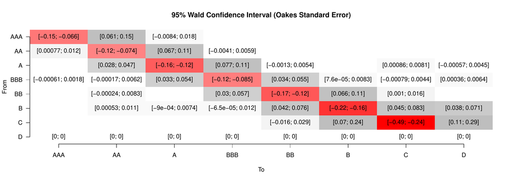

Figure 4: Confidence Interval

## 4 Bayesian inference

### 4.1 Gibbs sampler

Bladt and Sørensen (2005) show that the Gamma distribution $\Gamma(\phi,\psi)$ constitutes a conjugate prior for the off diagonal elements of the generator matrix under the continuous-time Markov chain likelihood function. The posterior distribution can then be derived as
$$\begin{aligned}
f(\mathbf{Q}|\{s(0),s(T)\})\propto& L(\mathbf{Q}|\{s(0),s(T)\})\prod_{i=1}^I\prod_{j \neq i} q_{ij}^{\phi_{ij}-1}\exp(-q_{ij}\psi_{i})\\\propto&\prod_{i=1}^I\prod_{j \neq i} q_{ij}^{N_{ij}(T)+\phi_{ij}-1}\exp(-q_{ij}(R_i(T)+\psi_{i})).
\end{aligned}$$
Based on these expressions, they describe a Gibbs sampling algorithm (GS) which in analogy to the EM algorithm iteratively simulates the missing data $N_{ij}(T)$ and $R_i(T)$ given the current parameter estimate and subsequently draws new parameter estimates given the imputed data. In order to use the method, the prior parameters have to be specified as a `"list"` object named `prior`. Thereby, the first element of the list has to be an $I \times J$ matrix of the Gamma parameters $\phi_{ij}$ and the second element a vector of length $I$ with the parameters $\psi_i$. Consider, e.g.,

```r
  pr <- list()
  pr[[1]] <- matrix(1, 8, 8)
  pr[[1]][8,] <- 0
  pr[[2]] <- c(rep(5, 7), Inf)
```

as a simple example, where $\phi_{ij}=1$, $\psi_i=5$ and there is an absorbing state $8$, which can be specified by determining $\phi_{\cdot,8}=0$ and $\psi_{8}=\infty$. As for the EM algorithm we need to provide a matrix of *absolute*, rather than relative, transition frequencies as input data (in our example `tm=tm_abs`). Furthermore, the length of the burn-in period must be chosen (here: `burnin=1000`). Convergence of the algorithm is evaluated by the approach of Heidelberger and Welch (1981), which is implemented in the R package [*coda*](https://CRAN.R-project.org/package=coda), see Plummer et al. (2006). The advantage of this method is that it can be applied to single chains; a shortcoming is that, as for similar methods, evaluation with multiple parameters is time consuming. Thus, besides specifying a p-value for the convergence test by the argument `conv_pvalue`, one can also set a frequency criterion `conv_freq` for how often with an equidistant number of trials convergence shall be checked. By default, `conv_pvalue=0.05` and `conv_freq=10`. One should notice that as the method of Heidelberger and Welch (1981) is a two sample location test for comparing the stability of the parameter estimates at the beginning and the end of the Markov chain, the hypotheses are set so that an increasing p-value implies a stricter convergence criterion. Another stopping rule is the maximum number of iterations `niter`, which by default is set as `niter=1e04`. If convergence according to the method of Heidelberger and Welch (1981) is not given before the maximum number of iterations is reached, a warning is displayed.

Setting the `method` argument to the value `"GS"` will then lead the generic generator matrix estimation method to provide a posterior mean estimate

```r
  gmgs <- gm(tm=tm_abs, te=1, method="GS", prior=pr, burnin=1000)
  plot(gmgs)
```

The result can be seen in figure 5.

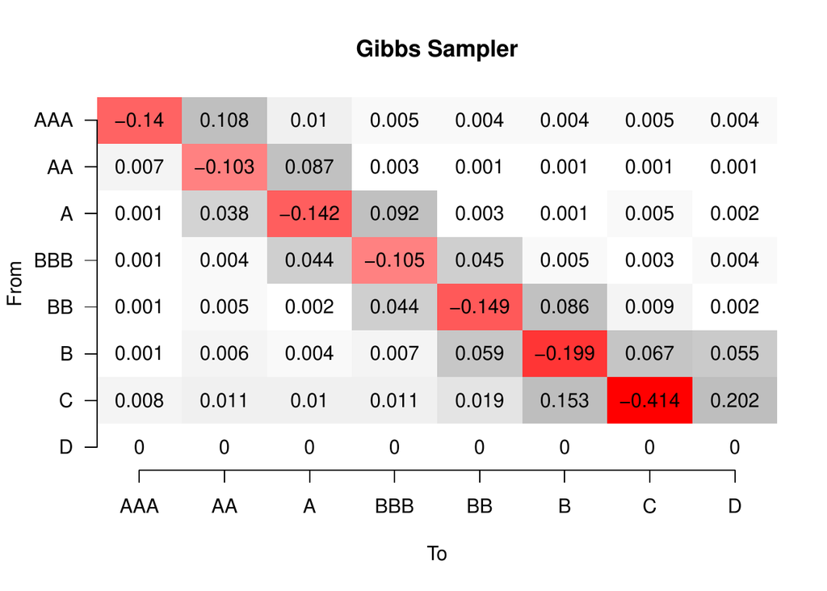

Figure 5: Posterior Mean Estimate

### 4.2 Endpoint-conditioned path sampling

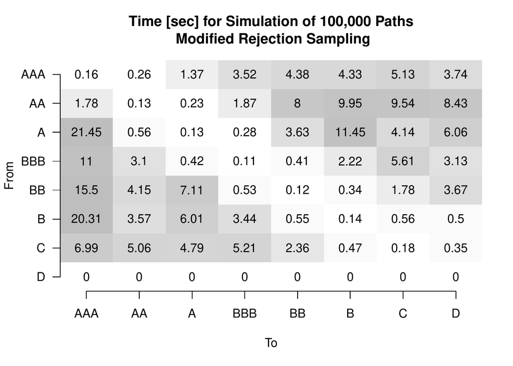

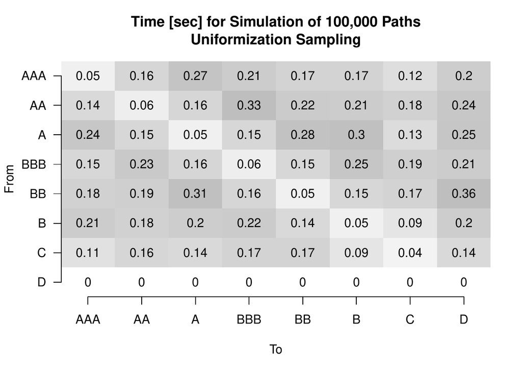

Figure 6: Endpoint-Conditioned Trajectory Sampling

```r
speedmat_modrej <- matrix(0, 8, 8)
speedmat_unif <- matrix(0, 8, 8)
tpm <- expm(gmgs$par)
for(i in 1:7){
  for(j in 1:8){
    elem <- matrix(0, 8, 8)
    elem[i,j] <- 1e5
    t0 <- proc.time()
    rNijTRiT_ModRej(elem, 1, gmgs$par)
    speedmat_modrej[i,j] <- (proc.time() - t0)[3]
    t0 <- proc.time()
    rNijTRiT_Unif(elem, 1, gmgs$par,tpm)
    speedmat_unif[i,j] <- (proc.time() - t0)[3]
  }
}

plotM(speedmat_modrej,
      main="Time for Simulation of 100,000 Paths\nModified Rejection Sampling",
      xnames=rownames(tm_abs), ynames=colnames(tm_abs))
plotM(speedmat_unif,
      main="Time for Simulation of 100,000 Paths\nUniformization Sampling",
      xnames=rownames(tm_abs), ynames=colnames(tm_abs))
```

Although in this example, the uniformization sampling approach clearly outperforms modified rejection sampling, it has to be mentioned that the computing time for deriving discrete time state transitions in the uniformization approach (which is carried out by using the matrix exponential) is not included, because it is only calculated once in each Gibbs sampling iteration step. Moreover, rejection rates of the approach of Nielsen (2002) might be lower if trajectories are sampled for a whole row of a transition matrix and not single initial and end state combinations because then more than one possible path ending can be accepted in a single draw. Therefore, to provide the option to combine the individual strengths of both approaches, it is possible to set `sampl_method="Comb"` and provide a matrix with entries of either `"M"` or `"U"` for the optional argument `combmat`, specifying which algorithm shall be used for simulating trajectories for the specific start and endpoint combination. Moreover, it is possible to include an own external sampling algorithm implementation by specifying `method="Ext"` and an argument `sampl_func` with a sampling function of the format

```r
  sf <- function(tmabs, te, gmest) {
    ### Derive Expected Holding Times (RiT) and Number of State Transitions (NijT)
    return(list(RiT=..., NijT=...))
  }
```

Thereby, the matrix of absolute transition frequencies `tmabs`, the time interval for the discrete-time transitions `te` and the current parameter estimate of the Gibbs sampler `gmest` are input variables to this function and a vector of cumulative simulated holding times `RiT` and a matrix of continuous-time state changes `NijT` needs to be returned.

### 4.3 Parallelization

As the numerical performance of the Gibbs sampling algorithm is severely dependent on the performance of the endpoint conditioned path sampling algorithm, we would like to briefly point out that the whole method can also be run in parallel. This can be achieved by setting up a number of `nco` independent chains with `N/nco` iterations each, whereas `N` denotes the total number of iterations and `nco` the number of parallel threads. As long as the initial states of the chain are forgotten, the single generator matrix draws can be seen as independent realizations. Thus, a burnin period must be considered in every thread and `conv_pvalue` has to be set to $1$ in order to ensure that the predetermined number of iterations is reached. Without loss of generality we use the packages [*foreach*](https://CRAN.R-project.org/package=foreach) (Microsoft and Weston 2017) and [*doParallel*](https://CRAN.R-project.org/package=doParallel) (Corporation and Weston 2017) to provide with a simple example.

```r
library(foreach)
library(doParallel)
N <- 1e5
nco <- detectCores()
cl <- makeCluster(nco)
registerDoParallel(cl)
gspar=foreach(i=1:nco, .packages=c("ctmcd", "expm")) %dopar%
  gm(tm=tm_abs, te=1, method="GS", burnin=1000, prior=pr,
     conv_pvalue=1, niter=N / nco)
stopCluster(cl)

### Derive Estimate
parlist <- lapply(gspar, function(x) x$par)
parest <- Reduce('+', parlist) / nco
```

In this multiple chain setting, convergence can be analyzed by the potential scale reduction factor diagnostic of Gelman and Rubin (1992). The potential scale reduction factor describes by what fraction the variance of the draws in the chain can be reduced if the chain is extended to an infinite length. Convergence is assumed when the factor is close to $1$. Rules of thumb on how close its value should be are, e.g., $1.2$, see Bolker (2008) or $1.1$, see Gelman et al. (2011). With the absorbing default state and diagonal elements being only a linear combination of the parameters in the single rows, chains for $49$ parameters have to be evaluated. This can be conducted by employing the multivariate extension of the originally univariate factor, which has been introduced by Brooks and Gelman (1998).

```r
### Check Convergence
library(coda)
chainlist <- as.mcmc.list(lapply(gspar, function(x) {
    as.mcmc(do.call(rbind, lapply(x$draws, as.vector)))
}))
parchainlist <- lapply(chainlist,
                       function(x) x[,as.vector(parest) > 0])
gelman.diag(parchainlist)
```

Employing the implementation of this diagnostic in the *coda* package, we derive a multivariate potential scale reduction factor of $1.01$ in this example. Thus, convergence may be assumed.

### 4.4 Credibility intervals

After having discussed various aspects of point estimation, an example for Bayesian interval estimation shall be presented as well. Bladt and Sørensen (2009) show that equal-tailed credibility intervals can be easily obtained from samples of the joint posterior distribution by empirical quantiles
$$[q_{ij,\lceil L\frac{\alpha}{2}\rceil},q_{ij,\lceil L\frac{1-\alpha}{2}\rceil}].$$
Calling `gmci()`, the generic function for generator matrix interval estimates, and specifying that an interval based on a Gibbs sampling object (here: `gmgs`) shall be derived will automatically call the `ciGS()` subroutine and yield an equal-tailed credibility interval as outlined above. Setting a confidence level `alpha=0.05` will then yield the estimate which can be seen in figure 7.

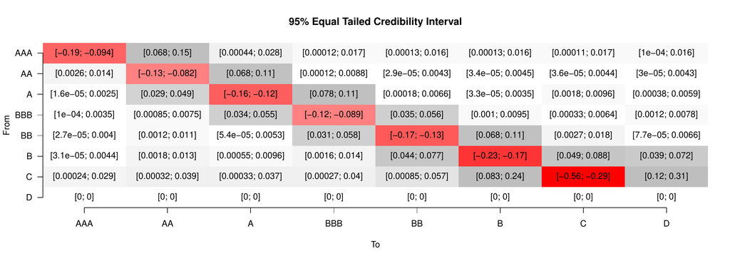

Figure 7: Credibility Interval

```r
cigs <- gmci(gm=gmgs, alpha=0.05)
plot(cigs)
```

## 5 Comparison of Approaches

The approaches `"DA"`, `"WA"`, `"EM"` and `"GS"` are suitable for state spaces of size $2$ or greater. However, with a state space of size $2$, the approaches diagonal adjustment and weighted adjustment will always yield the same result as there is only one possible rearrangement of off-diagonal elements in this case. Method `"QO"` requires a state space of at least size $3$ as two off diagonal elements for each row of a generator matrix are required to perform the implemented sorting scheme.

Figure 8 shows how the methods scale concerning numerical performance. The simulation study shows examples for the average time in seconds to perform an estimate with each of the methods outlined in this manuscript. Thereby, the EM algorithm and the Gibbs sampler are run for 100 iterations each and the data on which the estimates are performed is generated by distributing 1000 and respectively, 10000 discrete-time transitions over a single unit time horizon uniformly over matrices of dimension $2\times2$ to $10\times10$. The estimation procedures are repeated 1000 times and the mean execution times are summarized in the graphics below. One can recognize that the matrix logarithm adjustment approaches require by far less computation time than the EM algorithm and the Gibbs sampler and that with increasing dimension of the state space, computing time is increasing as well. Moreover, one can also identify that the matrix logarithm adjustment approaches and the EM algorithm are - in contrast to the Gibbs sampler - almost only dependent on the size of the state space and not the number of discrete-time transitions in the sample.

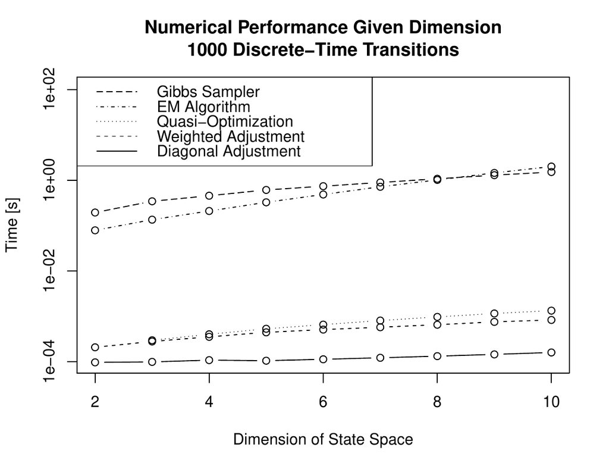

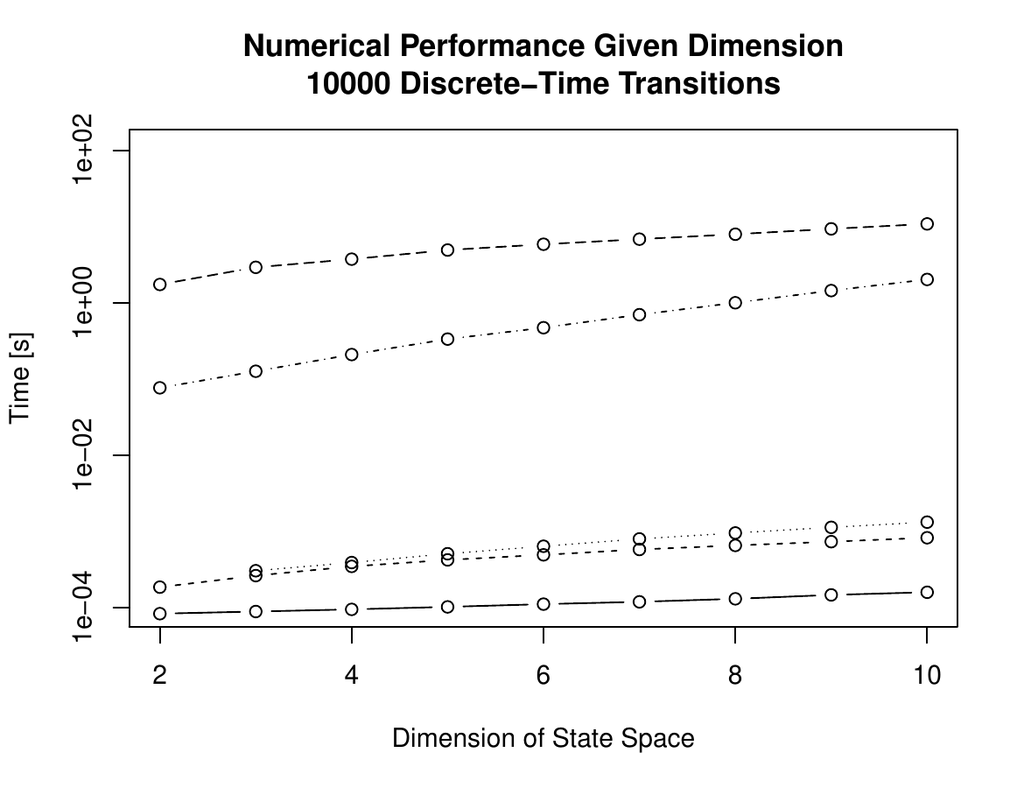

Figure 8: Speed Comparison

## 6 Profiles of Discrete-Time Transitions into Absorbing States

Based on the derived parameter estimates, predictions about discrete-time transitions into absorbing states of the Markov chain can be made and moreover, systemized as a function of the length of the discrete time interval. In the credit rating example shown in this paper, such functions are discrete time probabilities of default of a given initial rating category depending on the time horizon (in years) and shall be called probability of default profiles in the following. Thereby, an advantage of the Bayesian approach is that in contrast to the other methods outlined, interval estimates for such profiles can be easily derived. This involves the computation of empirical quantiles $p_{t_a,ij,\frac{\alpha}{2}}$ and $p_{t_a,ij,1-\frac{\alpha}{2}}$ of all elements of the discrete time transition matrix estimates
$$(\mathbf{P}_{t_a,1},\ldots , \mathbf{P}_{t_a,L})=(\exp(\mathbf{Q}_1t_a),\ldots,\exp(\mathbf{Q}_L t_a))$$
given the single Gibbs sampling generator matrix draws $\mathbf{Q}_1,\ldots , \mathbf{Q}_L$, see Bladt and Sørensen (2009).

For the seven possible initial states in the credit rating example, probability-of-default profiles can then be obtained using the following code, the results are shown in figure 9.

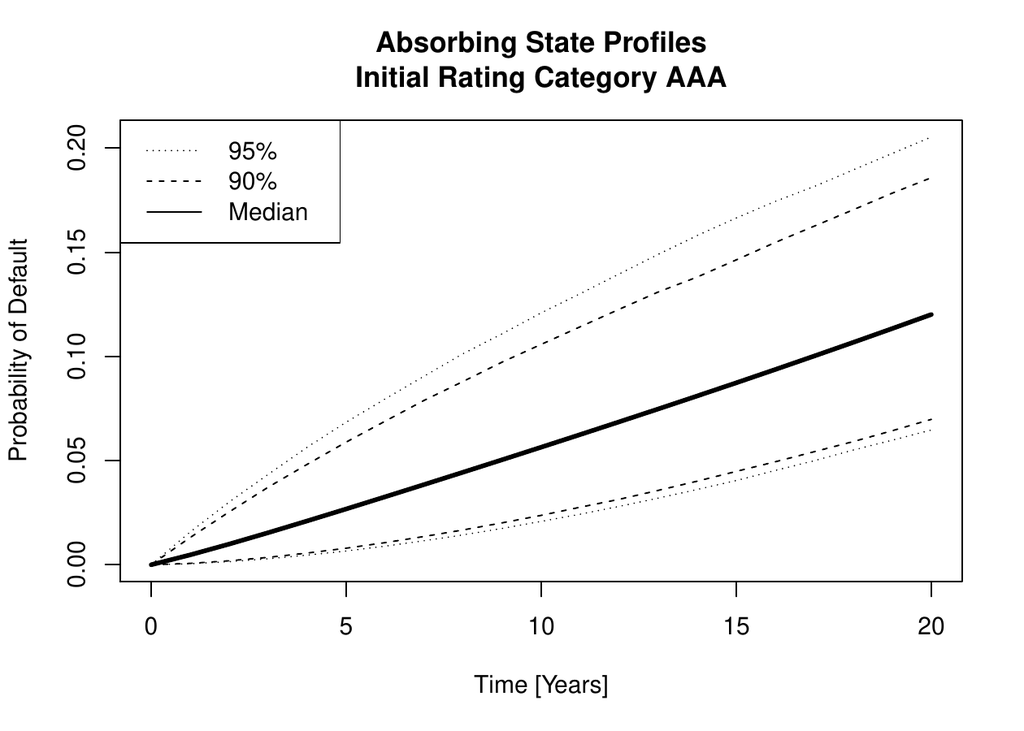

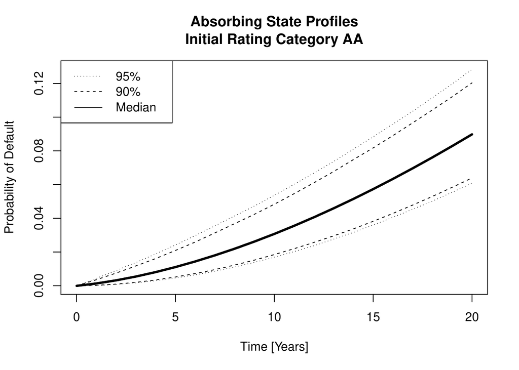

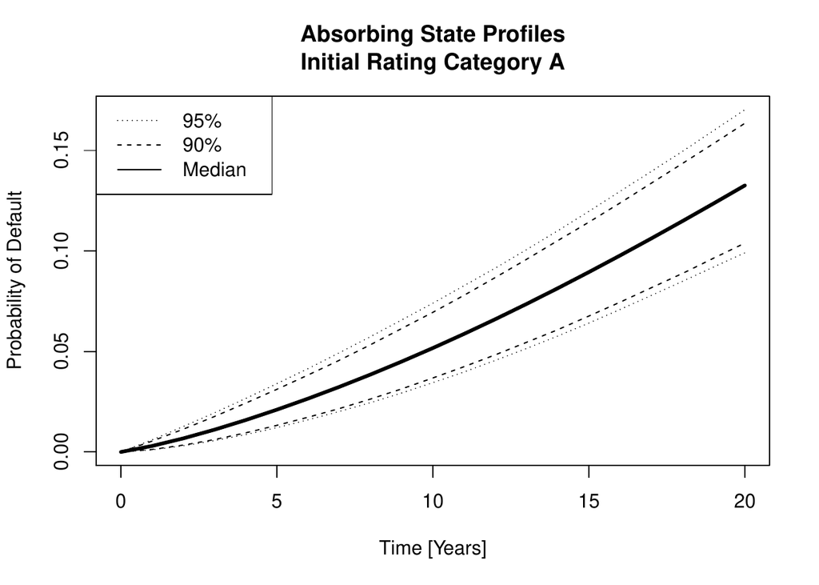

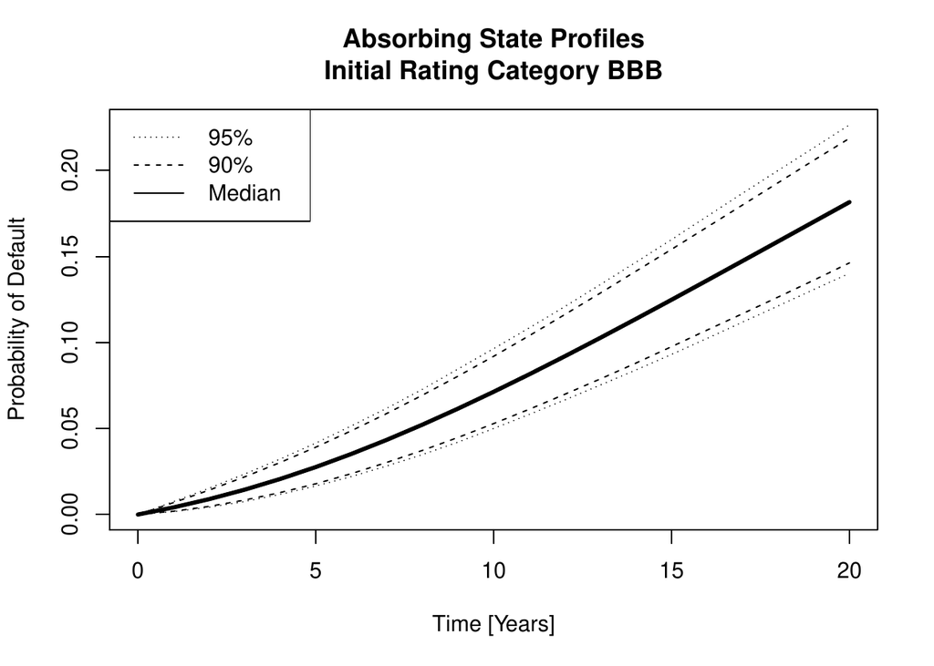

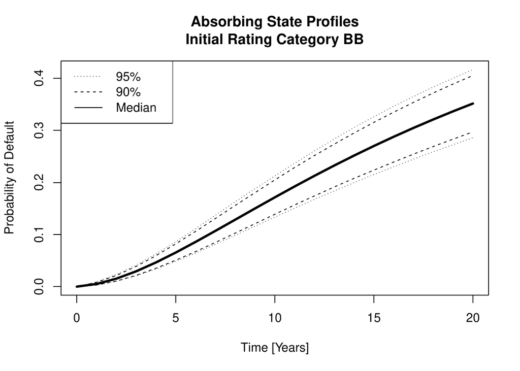

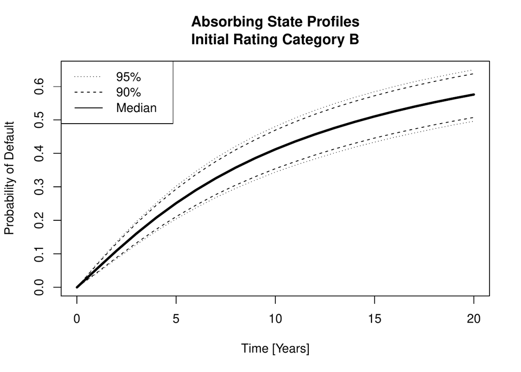

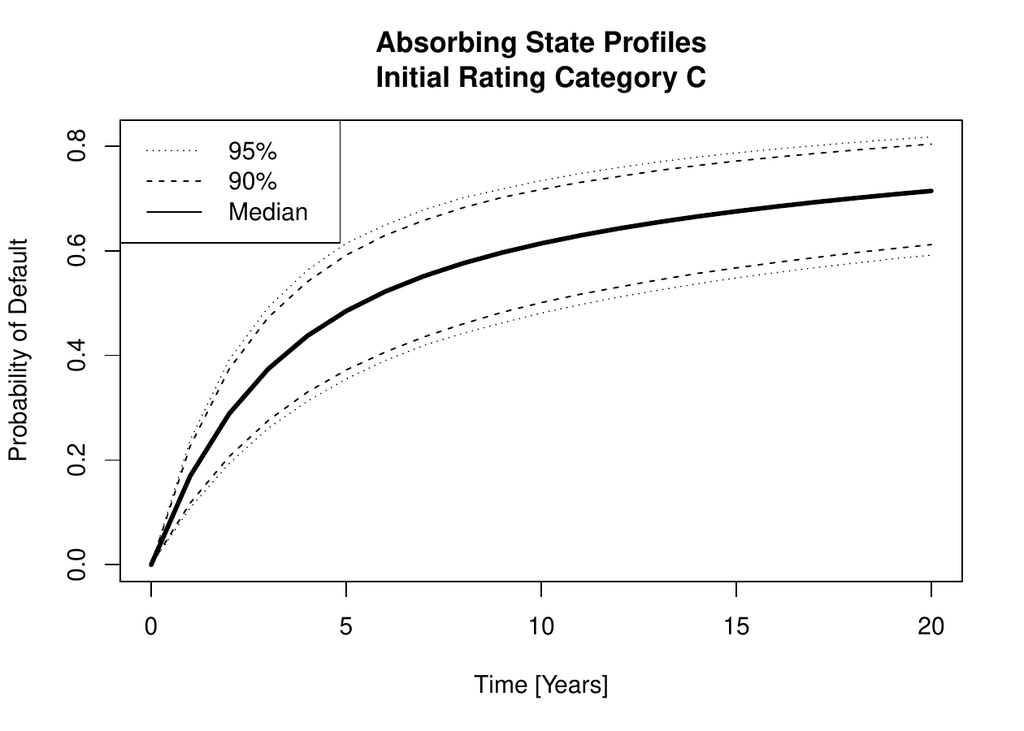

Figure 9: Probability-of-Default Profiles

```r
tmax <- 20
for(cat in 1:7){
  absStvec <- sapply(1:tmax, function(t) expm(gmgs$par * t)[cat,8])
  quantMat <- matrix(0, 4, tmax + 1)
  for(t in 1:tmax){
    dtdraws <- lapply(gmgs$draws, function(x) expm(t * x))
    drawvec <- sapply(1:length(gmgs$draws), function(x) dtdraws[[x]][cat,8])
    quantMat[,t + 1] <- quantile(drawvec, c(.025, .05, .95, .975))
  }
  plot(0:tmax, c(0, absStvec), t="l", lwd=3, ylim=c(0, max(quantMat)),
       main=paste0("Absorbing State Profiles\nInitial Rating Category ",
                   rownames(tm_abs)[cat]),
       xlab="Time [Years]", ylab="Probability of Default")
  for(i in 1:4)
    lines(0:tmax, quantMat[i,], lty=c(3, 2, 2, 3)[i])
  legend("topleft", lty=c(3, 2, 1), c("95%", "90%", "Median"))
}
```

Complementary to the solid line, which represents the posterior mean estimate based discrete-time probability of default predictions, pointwise credibility intervals for $\alpha=0.05$ and $\alpha=0.1$ are computed here. As expected, one can recognize that with increasing time horizon, the width of the intervals is increasing as well. Furthermore, the width of intervals increases with decreasing number of observations in the specific category. This can be seen, e.g., for the profile with pointwise intervals of initial rating category "AAA".

## 7 Summary

The problem of estimating the parameters of a continuous-time Markov chain from discrete-time data occurs in a wide range of applications and especially plays an important role in gene sequence data analysis and rating based credit risk modeling. This paper introduces and illustrates the *ctmcd* package, which provides an implementation of different approaches to derive such estimates. It supports matrix logarithm-based methods with diagonal and weighted adjustment as well as a quasi-optimization procedure. Moreover, maximum likelihood estimation is implemented by an instance of the EM algorithm and Bayesian estimates can be derived by a Gibbs sampling procedure. For the latter two approaches also interval estimates can be obtained. The Bayesian approach can be used to derive pointwise credibility intervals of discrete-time transition probabilities and systematic profiles of discrete-time transition probabilities into absorbing states given the corresponding time horizon. Above all, a matrix plot function is provided and can be used to visualize both point and interval estimates.

## 8 Acknowledgements

The author thanks two anonymous referees for their thorough review and highly appreciates the comments and suggestions which significantly contributed to increasing the quality of the R package *ctmcd* and this manuscript.

### 8.1 Supplementary materials

Supplementary materials are available in addition to this article. It can be downloaded at RJ-2017-038.zip

### 8.2 CRAN packages used

msm, ctmcd, coda, foreach, doParallel

### 8.3 CRAN Task Views implied by cited packages

Bayesian, Distributions, GraphicalModels, HighPerformanceComputing, Survival

M. Bladt and M. Sørensen. Efficient estimation of transition rates between credit ratings from observations at discrete time points. *Quantitative Finance*, 9(2): 147–160, 2009. URL https://doi.org/10.1080/14697680802624948.

M. Bladt and M. Sørensen. Statistical inference for discretely observed Markov jump processes. *Journal of the Royal Statistical Society B*, 67(3): 395–410, 2005. URL https://doi.org/10.1111/j.1467-9868.2005.00508.x.

B. Bolker. *Ecological models and data in r.* Princeton University Press, 2008.

S. P. Brooks and A. Gelman. General methods for monitoring convergence of iterative simulations. *Journal of Computational and Graphical Statistics*, 7(4): 434–455, 1998.

M.-H. Chen et al. *Bayesian phylogenetics: Methods, algorithms, and applications.* CRC Press, 2014. URL https://doi.org/10.1093/sysbio/syv063.

M. Corporation and S. Weston. *doParallel: Foreach parallel adaptor for the ’parallel’ package.* 2017. URL https://CRAN.R-project.org/package=doParallel. R package version 1.0.11.

T. Cubitt et al. The complexity of relating quantum channels to master equations. *Communications in Mathematical Physics*, 310(2): 383–418, 2012. URL https://doi.org/10.1007/s00220-011-1402-y.

J. R. Cuthbert. On uniqueness of the logarithm for Markov semi-groups. *Journal of the London Mathematical Society*, s2-4(4): 623–630, 1972.

J. R. Cuthbert. The logarithm function for finite-state Markov semi-groups. *Journal of the London Mathematical Society*, s2-6(3): 524–532, 1973.

G. Dorfleitner and C. Priberny. A quantitative model for structured microfinance. *The Quarterly Review of Economics and Finance*, 53(1): 12–22, 2013. URL https://doi.org/10.1016/j.qref.2012.10.005.

G. Elfving. Zur Theorie der Markoffschen Ketten. *Acta Societatis Scientiarum Fennicae*, A.2(8): 1–17, 1937.

S. N. Ethier and T. G. Kurtz. *Markov processes: Characterization and convergence.* Wiley, 2005. URL https://doi.org/10.1002/9780470316658.

P. Fearnhead and C. Sherlock. An exact Gibbs sampler for the Markov-modulated Poisson process. *Journal of the Royal Statistical Society B*, 68: 767–784, 2006. URL https://doi.org/10.1111/j.1467-9868.2006.00566.x.

J. Fintzi. ECctmc: Simulation from endpoint-conditioned continuous time Markov chains. 2016.

A. Gelman et al. Inference from simulations and monitoring convergence. *Handbook of Markov Chain Monte Carlo*, 163–174, 2011. URL https://doi.org/10.1201/b10905-7.

A. Gelman and D. B. Rubin. Inference from iterative simulation using multiple sequences. *Statistical Science*, 457–472, 1992. URL https://doi.org/10.1214/ss/1177011136.

P. Heidelberger and P. D. Welch. A spectral method for confidence interval generation and run length control in simulations. *Communications of the ACM*, 24(4): 233–245, 1981. URL https://doi.org/10.1145/358598.358630.

A. Hobolth. A Markov chain Monte Carlo expectation maximization algorithm for statistical analysis of DNA sequence evolution with neighbor-dependent substitution rates. *Journal of Computational and Graphical Statistics*, 17(1): 1–25, 2008. URL https://doi.org/10.1198/106186008X289010.

A. Hobolth and E. A. Stone. Simulation from endpoint-conditioned, continuous-time Markov chains on a finite state space, with applications to molecular evolution. *Annals of Applied Statistics*, 3(3): 1204–1231, 2009. URL https://doi.org/10.1214/09-AOAS247.

M. Hughes and R. Werner. Choosing Markovian credit migration matrices by nonlinar optimization. *Risks*, 4(3): 31, 2016. URL https://doi.org/10.3390/risks4030031.

Y. Inamura. Estimating continuous time transition matrices from discretely observed data. *Bank of Japan Working Paper Series*, 2006. URL https://www.boj.or.jp/en/research/wps_rev/wps_2006/data/wp06e07.pdf.

R. B. Israel et al. Finding generators for Markov chains via empirical transition matrices, with applications to credit ratings. *Mathematical Finance*, 11(2): 245–265, 2001. URL https://doi.org/10.1111/1467-9965.00114.

C. H. Jackson et al. Multi-state models for panel data: The msm package for R. *Journal of Statistical Software*, 38(8): 1–29, 2011. URL https://doi.org/10.18637/jss.v038.i08.

J. Kalbfleisch and J. F. Lawless. The analysis of panel data under a Markov assumption. *Journal of the American Statistical Association*, 80(392): 863–871, 1985. URL https://doi.org/10.1080/01621459.1985.10478195.

E. Kreinin and M. Sidelnikova. Regularization algorithms for transition matrices. *Algo Research Quarterly*, 4(1): 23–40, 2001.

Microsoft and S. Weston. *Foreach: Provides foreach looping construct for r.* 2017. URL https://CRAN.R-project.org/package=foreach. R package version 1.4.4.

R. Nielsen. Mapping mutations on phylogenies. *Systematic Biology*, 51(5): 729–739, 2002. URL https://doi.org/10.1080/10635150290102393.

J. R. Norris. *Markov chains.* Cambridge University Press, 1998. URL https://doi.org/10.1017/CBO9780511810633.

D. Oakes. Direct calculation of the information matrix via the EM algorithm. *Journal of the Royal Statistical Society: Series B (Statistical Methodology)*, 61(2): 479–482, 1999. URL https://doi.org/10.1111/1467-9868.00188.

M. Pfeuffer. Generator matrix approximation based on discrete-time rating migration data. 2016.

M. Plummer, N. Best, K. Cowles and K. Vines. CODA: Convergence diagnosis and output analysis for MCMC. *R news*, 6(1): 7–11, 2006.

M. J. Powell. The BOBYQA algorithm for bound constrained optimization without derivatives. *Cambridge NA Report NA2009/06, University of Cambridge, Cambridge*, 2009.

B. Singer and S. Spilerman. The representation of social processes by Markov models. *American Journal of Sociology*, 82(1): 1–54, 1976.

G. Smith and G. dos Reis. Robust and consistent estimation of generators in credit risk. *Quantitative Finance (To Appear)*, 2017. URL https://doi.org/10.1080/14697688.2017.1383627.

J. M. Speakman. Two markov chains with a common skeleton. *Zeitschrift für Wahrscheinlichkeitstheorie und Verwandte Gebiete*, 7(3): 224–224, 1967.

Standard and Poor’s. Global corporate rating transitions. 2000. URL https://cerep.esma.europa.eu/cerep-web/statistics/transitionMatrice.xhtml.

C. van Loan. Computing integrals involving the matrix exponential. *IEEE Transactions on Automatic Controls*, AC 23(3): 395–404, 1978.

K. L. Verbyla et al. The embedding problem for Markov models of nucleotide substitution. *PloS one*, 8(7): e69187, 2013. URL https://doi.org/10.1371/journal.pone.0069187.

T. Yavin et al. Transition probability matrix methodology for incremental risk charge. *Journal of Financial Engineering*, 1(1): 1450010, 2014. URL https://doi.org/10.1142/S234576861450010X.

M. Zhang and D. S. Small. Effect of vitamin A deficiency on respiratory infection: Causal inference for a discretely observed continuous-time non-stationary Markov process. *Canadian Journal of Statistics*, 40(4): 646–662, 2012. URL https://doi.org/10.1002/cjs.11161.